# Reconocimiento de Vehiculos - Vision por computador

```python
from google.colab import drive
drive.mount('/content/drive')
```

```python
%matplotlib inline

import glob
import os
import re

import matplotlib.image as mpimg
import pandas as pd
import PIL
import cv2
import matplotlib.pyplot as plt
import numpy as np
import math
import skimage.morphology as morph
from skimage import io, color
from PIL import Image
import skimage
```

## Funciones de utilidad

```python
def img_read(filename, mode = 'color'):
    if(mode == 'color'):
        return cv2.cvtColor(cv2.imread(filename),cv2.COLOR_BGR2RGB)
    elif(mode=='grayscale' or mode=='greyscale' or mode == 'gray' or mode == 'grey'):
        return cv2.imread(filename, cv2.IMREAD_GRAYSCALE)
    elif(mode=='yuv' or mode=='YUV'):
        return cv2.cvtColor(cv2.imread(filename),cv2.COLOR_BGR2YUV)
    elif(mode=='hsv' or mode=='HSV'):
        return cv2.cvtColor(cv2.imread(filename),cv2.COLOR_BGR2HSV)
    elif(mode=='lab' or mode=='LAB'):
        return cv2.cvtColor(cv2.imread(filename),cv2.COLOR_BGR2LAB)
    else:
        return None

def norm_image(img):
    img_pil = Image.fromarray(img)
    """
    Normalize PIL image

    Normalizes luminance to (mean,std)=(0,1), and applies a [1%, 99%] contrast stretch
    """
    img_y, img_b, img_r = img_pil.convert('YCbCr').split()

    img_y_np = np.asarray(img_y).astype(float)

    img_y_np /= 255
    img_y_np -= img_y_np.mean()
    img_y_np /= img_y_np.std()
    scale = np.max([np.abs(np.percentile(img_y_np, 1.0)),
                    np.abs(np.percentile(img_y_np, 99.0))])
    img_y_np = img_y_np / scale
    img_y_np = np.clip(img_y_np, -1.0, 1.0)
    img_y_np = (img_y_np + 1.0) / 2.0

    img_y_np = (img_y_np * 255 + 0.5).astype(np.uint8)

    img_y = Image.fromarray(img_y_np)

    img_ybr = Image.merge('YCbCr', (img_y, img_b, img_r))

    img_nrm = img_ybr.convert('RGB')

    open_cv_image = np.array(img_nrm)

    return open_cv_image

#Definir la función de transformación de la imagen (corrección gamma)
def gamma_correction(img, a, gamma):

    #Crear copia de la imagen tipo flotante dada la normalización
    img_copy = img.copy().astype(np.float32)/255.0
    #La función corrección gamma es de la forma ax^gamma donde x es la imagen de entrada
    res_gamma = cv2.pow(img_copy, gamma)
    res = cv2.multiply(res_gamma, a)

    #Asegurar que la los datos queden entre 0 y 255 y sean uint8
    res[res<0] = 0
    res = res*255.0
    res[res>255] = 255

    res = res.astype(np.uint8)

    return res

def histogram_equalization(img):

    #Crear matriz de ceros del tamaño de la imagen y tipo de dato flotante
    res = np.zeros(img.shape, np.float32)
    #Crear un vector 1-D de la matriz de la imagen es decir \aplanarla\
    img_raveled = img.ravel()
    #Generar el histograma normalizado de la imagen
    hist_norm = plt.hist(img_raveled, bins=255, range=(0.0, 255.0), density=True)
    #Limpiar la figura actual
    plt.clf()
    #hist_norm[0] es un vector de probabilidades. Añadir al vector el valor [1 - sumatoria de sus datos]
    pdf = hist_norm[0]
    np.append(pdf, 1.0 - np.sum(pdf))
    #Dado que se añade un dato se realiza la sumatoria de valores sobre todo el vector
    cdf = [np.sum(pdf[0:x]) for x in range(0,256)]
    #Hallar el valor mínimo y máximo de la imagen
    gmin = np.min(img)
    gmax = np.max(img)

    #Generar F(g) - Función de ecualización
    for g in range(0,256):
        res[img == g] = (gmax - gmin)*cdf[g] + gmin
    #Asegurar que los datos sean uint8 y esten en el rango correspondiente
    res[res<0] = 0
    res[res>255] = 255
    res = res.astype(np.uint8)
    return res

#definicion de funcion para la aplicacion del filtro de media.
def filtro_mediab(imag,k_size):
    #Aplica suavizado mediante la funcion blur
    res1 = cv2.blur(imag,(k_size,k_size),borderType=cv2.BORDER_REPLICATE )

    return res1

def filtro_media2d(imag,k_size):
    #Aplica suavizado mediante filter2D
    kernel = np.ones((k_size,k_size),np.float64)/(k_size**2)
    res2 = cv2.filter2D(imag, ddepth=-1, kernel= kernel, borderType=cv2.BORDER_REPLICATE)

    return res2

def minimum_filter(img,k_size):
    #Crear matriz de ceros del tamaño de imagen de entrada
    res = np.zeros(img.shape, np.uint8)
    #Definir el radio del kernel
    r = math.floor(k_size/2)
    #Recorrer cada posición i,j de la imagen con el kernel
    for i in range(r, img.shape[0]-r):
        for j in range(r, img.shape[1]-r):
            #Tamaño de la ventana
            window = img[i-r:i+r+1,j-r:j+r+1]
            #Cambiar el valor de la posición i,j de la imagen por el de la ventana
            min_val = np.min(window)
            res[i,j] = min_val
    return res

#Definir función de Filtro del Máximo
def maximum_filter(img,k_size):
    #Crear una matriz de ceros del tamaño de la imagen de entrada
    res = np.zeros(img.shape, np.uint8)
    #Radio del kernel
    r = math.floor(k_size/2)
    #Recorrer cada posición i,j de la imagen con el kernel
    for i in range(r, img.shape[0]-r):
        for j in range(r, img.shape[1]-r):
            #Tamaño de la ventana
            window = img[i-r:i+r+1,j-r:j+r+1]
            #Cambiar el valor de la posición i,j de la imagen por el de la ventana
            max_val = np.max(window)
            res[i,j] = max_val
    return res
```

# Preprocesamiento de las imagenes

## Analisis de canales

Se realiza un analisis visual de imagenes escogidas de manera aleatora con el fin de determinar si hay algun canal el cual pueda servir mejor para el preprocesamiento

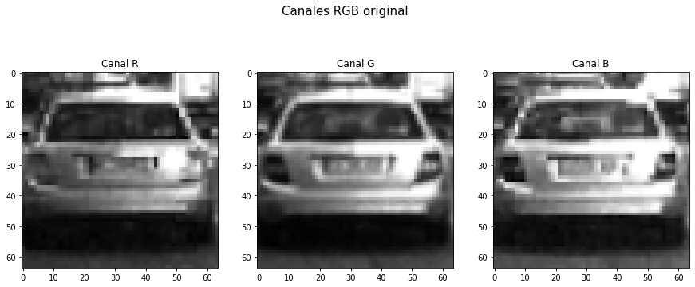

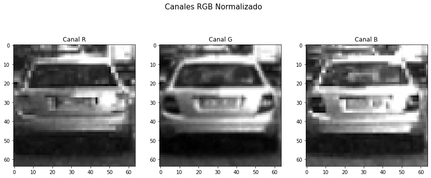

```python
image_path = '145.png'
img_rgb = img_read('/content/drive/MyDrive/GitHub/data/vehicles/'+image_path)
img_norm = norm_image(img_rgb)

#Modelo RGB
img_R = img_rgb[:,:,0]
img_G = img_rgb[:,:,1]
img_B = img_rgb[:,:,2]

fig, (ax1, ax2, ax3) = plt.subplots(1,3, figsize=(15, 6))

fig.suptitle('Canales RGB original', fontsize=15)
ax1.set_title('Canal R')
ax1.imshow(img_R, cmap='gray')
ax2.set_title('Canal G')
ax2.imshow(img_G, cmap='gray')
ax3.set_title('Canal B')
ax3.imshow(img_B, cmap='gray')

#Modelo RGB
img_R = img_norm[:,:,0]
img_G = img_norm[:,:,1]
img_B = img_norm[:,:,2]

fig, (ax1, ax2, ax3) = plt.subplots(1,3, figsize=(15, 6))

fig.suptitle('Canales RGB Normalizado', fontsize=15)
ax1.set_title('Canal R')
ax1.imshow(img_R, cmap='gray')
ax2.set_title('Canal G')
ax2.imshow(img_G, cmap='gray')
ax3.set_title('Canal B')
ax3.imshow(img_B, cmap='gray')
```

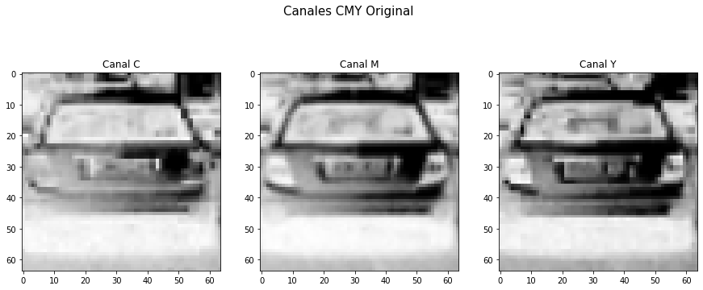

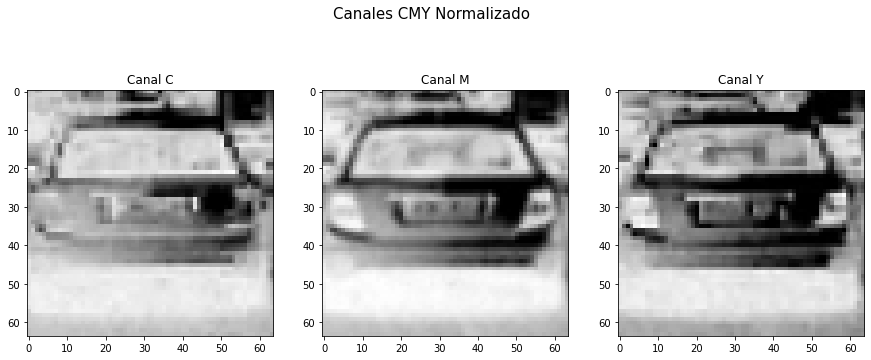

```python
img_cmy = img_read('/content/drive/MyDrive/GitHub/data/vehicles/'+image_path)
img_cmy_norm = norm_image(img_cmy)

#Modelo CMY
img_C= 255 - img_cmy[:,:,0]
img_M = 255 - img_cmy[:,:,1]
img_Y = 255 - img_cmy[:,:,2]

fig, (ax1, ax2, ax3) = plt.subplots(1,3, figsize=(15, 6))

fig.suptitle('Canales CMY Original', fontsize=15)
ax1.set_title('Canal C')
ax1.imshow(img_C, cmap='gray')
ax2.set_title('Canal M')
ax2.imshow(img_M, cmap='gray')
ax3.set_title('Canal Y')
ax3.imshow(img_Y, cmap='gray')

#Modelo CMY
img_C= 255 - img_cmy_norm[:,:,0]
img_M = 255 - img_cmy_norm[:,:,1]
img_Y = 255 - img_cmy_norm[:,:,2]

fig, (ax1, ax2, ax3) = plt.subplots(1,3, figsize=(15, 6))

fig.suptitle('Canales CMY Normalizado', fontsize=15)
ax1.set_title('Canal C')
ax1.imshow(img_C, cmap='gray')
ax2.set_title('Canal M')
ax2.imshow(img_M, cmap='gray')
ax3.set_title('Canal Y')
ax3.imshow(img_Y, cmap='gray')
```

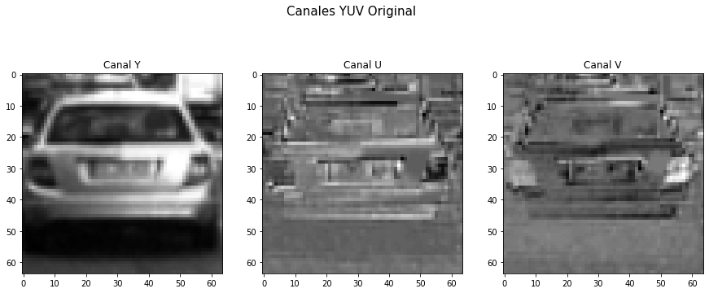

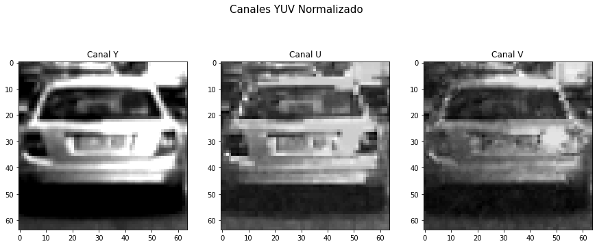

```python
img_yuv = img_read('/content/drive/MyDrive/GitHub/data/vehicles/'+image_path, 'yuv')
img_yuv_norm = norm_image(img_yuv)

#Modelo YUV

img_Y = img_yuv[:,:,0]
img_U =  img_yuv[:,:,1]
img_V = img_yuv[:,:,2]

fig, (ax1, ax2, ax3) = plt.subplots(1,3, figsize=(15, 6))

fig.suptitle('Canales YUV Original', fontsize=15)
ax1.set_title('Canal Y')
ax1.imshow(img_Y, cmap='gray')
ax2.set_title('Canal U')
ax2.imshow(img_U, cmap='gray')
ax3.set_title('Canal V')
ax3.imshow(img_V, cmap='gray')

#Modelo YUV

img_Y = img_yuv_norm[:,:,0]
img_U =  img_yuv_norm[:,:,1]
img_V = img_yuv_norm[:,:,2]

fig, (ax1, ax2, ax3) = plt.subplots(1,3, figsize=(15, 6))

fig.suptitle('Canales YUV Normalizado', fontsize=15)
ax1.set_title('Canal Y')
ax1.imshow(img_Y, cmap='gray')
ax2.set_title('Canal U')
ax2.imshow(img_U, cmap='gray')
ax3.set_title('Canal V')
ax3.imshow(img_V, cmap='gray')
```

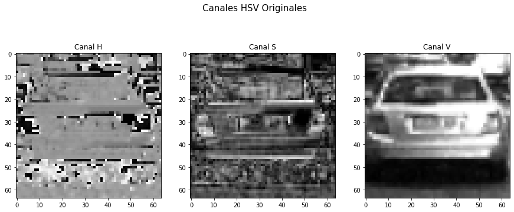

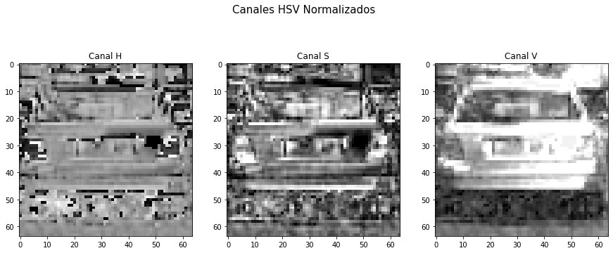

```python
img_hsv = img_read('/content/drive/MyDrive/GitHub/data/vehicles/'+image_path, 'hsv')
img_hsv_norm = norm_image(img_hsv)

#Modelo HSV

img_H = img_hsv[:,:,0]
img_S =  img_hsv[:,:,1]
img_V = img_hsv[:,:,2]

fig, (ax1, ax2, ax3) = plt.subplots(1,3, figsize=(15, 6))

fig.suptitle('Canales HSV Originales', fontsize=15)
ax1.set_title('Canal H')
ax1.imshow(img_H, cmap='gray')
ax2.set_title('Canal S')
ax2.imshow(img_S, cmap='gray')
ax3.set_title('Canal V')
ax3.imshow(img_V, cmap='gray')

#Modelo HSV

img_H = img_hsv_norm[:,:,0]
img_S =  img_hsv_norm[:,:,1]
img_V = img_hsv_norm[:,:,2]

fig, (ax1, ax2, ax3) = plt.subplots(1,3, figsize=(15, 6))

fig.suptitle('Canales HSV Normalizados', fontsize=15)
ax1.set_title('Canal H')
ax1.imshow(img_H, cmap='gray')
ax2.set_title('Canal S')
ax2.imshow(img_S, cmap='gray')
ax3.set_title('Canal V')
ax3.imshow(img_V, cmap='gray')
```

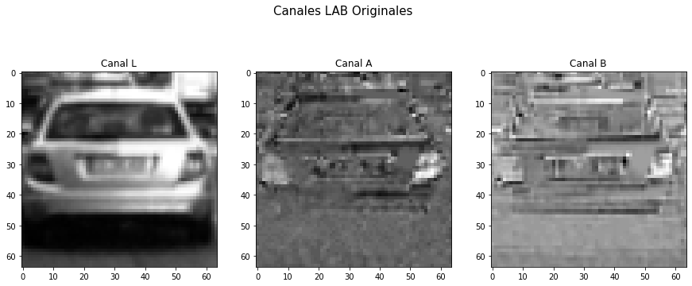

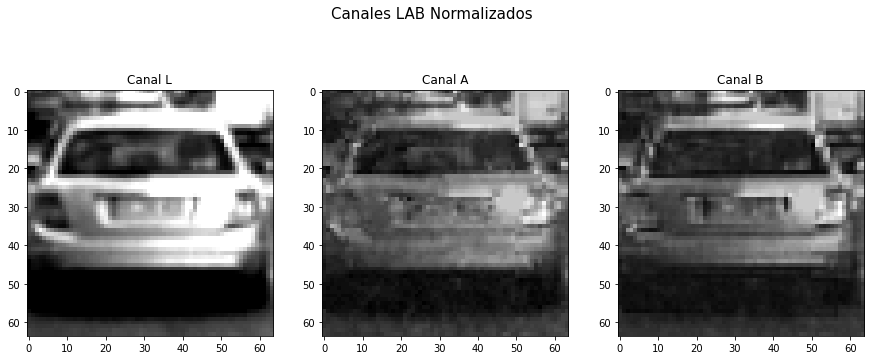

```python
img_lab = img_read('/content/drive/MyDrive/GitHub/data/vehicles/'+image_path, 'lab')
img_lab_norm = norm_image(img_lab)

#Modelo LAB

img_L = img_lab[:,:,0]
img_A =  img_lab[:,:,1]
img_B = img_lab[:,:,2]

fig, (ax1, ax2, ax3) = plt.subplots(1,3, figsize=(15, 6))
fig.suptitle('Canales LAB Originales', fontsize=15)
ax1.set_title('Canal L')
ax1.imshow(img_L, cmap='gray')
ax2.set_title('Canal A')
ax2.imshow(img_A, cmap='gray')
ax3.set_title('Canal B')
ax3.imshow(img_B, cmap='gray')

#Modelo LAB

img_L = img_lab_norm[:,:,0]
img_A =  img_lab_norm[:,:,1]
img_B = img_lab_norm[:,:,2]

fig, (ax1, ax2, ax3) = plt.subplots(1,3, figsize=(15, 6))
fig.suptitle('Canales LAB Normalizados', fontsize=15)
ax1.set_title('Canal L')
ax1.imshow(img_L, cmap='gray')
ax2.set_title('Canal A')
ax2.imshow(img_A, cmap='gray')
ax3.set_title('Canal B')
ax3.imshow(img_B, cmap='gray')
```

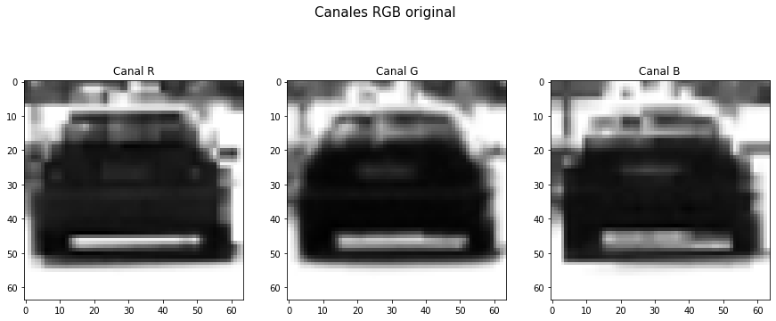

```python
image_path_one = '50.png'
img_rgb = img_read('/content/drive/MyDrive/GitHub/data/vehicles/'+image_path_one)

#Modelo RGB
img_R = img_rgb[:,:,0]
img_G = img_rgb[:,:,1]
img_B = img_rgb[:,:,2]

fig, (ax1, ax2, ax3) = plt.subplots(1,3, figsize=(15, 6))

fig.suptitle('Canales RGB original', fontsize=15)
ax1.set_title('Canal R')
ax1.imshow(img_R, cmap='gray')
ax2.set_title('Canal G')
ax2.imshow(img_G, cmap='gray')
ax3.set_title('Canal B')
ax3.imshow(img_B, cmap='gray')
```

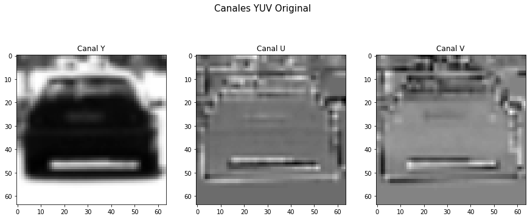

```python
img_yuv = img_read('/content/drive/MyDrive/GitHub/data/vehicles/'+image_path_one, 'yuv')

#Modelo YUV

img_Y = img_yuv[:,:,0]
img_U =  img_yuv[:,:,1]
img_V = img_yuv[:,:,2]

fig, (ax1, ax2, ax3) = plt.subplots(1,3, figsize=(15, 6))

fig.suptitle('Canales YUV Original', fontsize=15)
ax1.set_title('Canal Y')
ax1.imshow(img_Y, cmap='gray')
ax2.set_title('Canal U')
ax2.imshow(img_U, cmap='gray')
ax3.set_title('Canal V')
ax3.imshow(img_V, cmap='gray')
```

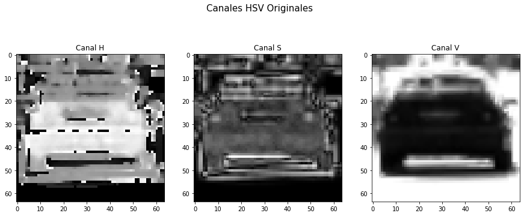

```python
img_hsv = img_read('/content/drive/MyDrive/GitHub/data/vehicles/'+image_path_one, 'hsv')

#Modelo HSV

img_H = img_hsv[:,:,0]
img_S =  img_hsv[:,:,1]
img_V = img_hsv[:,:,2]

fig, (ax1, ax2, ax3) = plt.subplots(1,3, figsize=(15, 6))

fig.suptitle('Canales HSV Originales', fontsize=15)
ax1.set_title('Canal H')
ax1.imshow(img_H, cmap='gray')
ax2.set_title('Canal S')
ax2.imshow(img_S, cmap='gray')
ax3.set_title('Canal V')
ax3.imshow(img_V, cmap='gray')
```

En esta prueba, los canales G(RGB) y Y(YUV) presentan el mayor contraste y muestran mejor el contorno del vehículo respecto al fondo. Se descartan los canales H y S del espectro HSV, pues el contorno del vehículo se mezcla con el fondo y no hay una distinción clara del objeto, al igual que los canales U y V del espectro YUV.

A continuación se les aplica un kernel de acentuación a las imagenes en estos dos canales para ver si mejora su contraste y definición.

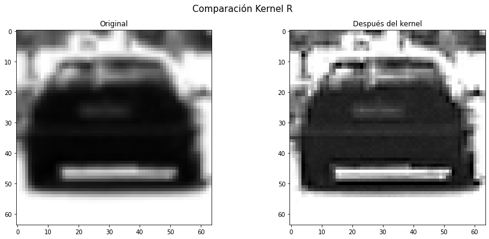

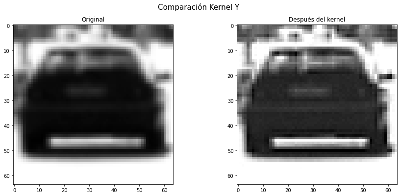

```python
sharp_kernel = np.array([[0,-1,0], [-1,5,-1], [0,-1,0]])
img_G_sharp = cv2.filter2D(img_G, -1, sharp_kernel)
img_Y_sharp = cv2.filter2D(img_Y, -1, sharp_kernel)

fig, (ax1, ax2) = plt.subplots(1,2, figsize=(15, 6))

fig.suptitle('Comparación Kernel R', fontsize=15)
ax1.set_title('Original')
ax1.imshow(img_G, cmap='gray')
ax2.set_title('Después del kernel')
ax2.imshow(img_G_sharp, cmap='gray')

fig, (ax1, ax2) = plt.subplots(1,2, figsize=(15, 6))

fig.suptitle('Comparación Kernel Y', fontsize=15)
ax1.set_title('Original')
ax1.imshow(img_Y, cmap='gray')
ax2.set_title('Después del kernel')
ax2.imshow(img_Y_sharp, cmap='gray')
```

Al aplicar el kernel de acentuación, se resaltan detalles que pueden ayudar a distinguir el auto, como la matrícula y las luces o reflectores.

#### Conclusion

Al analizar los canales se encontraron candidatos pero se observa que los canales no tienen el mismo comportamiento en todas las imagenes, por lo caul se decide trabajar con la imagen en todos sus canales

## Ecualizacion de la imagen

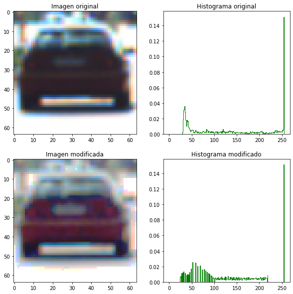

```python
#Definir la función ecualización del histograma cuyo parámetro es una imagen
img_rgb1 = img_read('/content/drive/MyDrive/GitHub/data/vehicles/'+image_path_one)
#Modelo RGB
img_G2 = img_rgb1

#Leer la imagen y aplicar la transformación ecualización del histograma sobre ésta

res_ecua = histogram_equalization(img_G2)

#Generar subplot 2x3 para mostrar imagen histograma y función de densidad acumulada
fig, arreglo_plots = plt.subplots(2,2 ,figsize=(10 ,10))
colors = ('r','g','b')

arreglo_plots[0,0].set_title('Imagen original')
arreglo_plots[0,0].imshow(img_G2, cmap='gray')
arreglo_plots[0,1].set_title('Histograma original')
img_array_i = img_G.ravel()
_=arreglo_plots[0,1].hist(img_array_i,histtype='step', bins=255 ,
                            range=(0.0, 255.0),density=True ,color=colors[1])

arreglo_plots[1,0].set_title('Imagen modificada')
arreglo_plots[1,0].imshow(res_ecua, cmap="gray")
arreglo_plots[1,1].set_title('Histograma modificado')
img_array_i = res_ecua.ravel()
_=arreglo_plots[1,1].hist(img_array_i,histtype='step', bins=255,
                          range=(0.0, 255.0),density=True, color=colors[1])
```

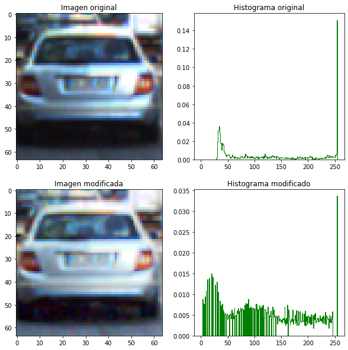

```python
image_path = "145.png"
#Definir la función ecualización del histograma cuyo parámetro es una imagen
img_rgb1 = img_read('/content/drive/MyDrive/GitHub/data/vehicles/'+image_path)
#Modelo RGB
img_G2 = img_rgb1

#Leer la imagen y aplicar la transformación ecualización del histograma sobre ésta

res_ecua2 = histogram_equalization(img_G2)

#Generar subplot 2x3 para mostrar imagen histograma y función de densidad acumulada
fig, arreglo_plots = plt.subplots(2,2 ,figsize=(10 ,10))
colors = ('r','g','b')

arreglo_plots[0,0].set_title('Imagen original')
arreglo_plots[0,0].imshow(img_G2, cmap='gray')
arreglo_plots[0,1].set_title('Histograma original')
img_array_i = img_G.ravel()
_=arreglo_plots[0,1].hist(img_array_i,histtype='step', bins=255 ,
                            range=(0.0, 255.0),density=True ,color=colors[1])

arreglo_plots[1,0].set_title('Imagen modificada')
arreglo_plots[1,0].imshow(res_ecua2, cmap="gray")
arreglo_plots[1,1].set_title('Histograma modificado')
img_array_i = res_ecua2.ravel()
_=arreglo_plots[1,1].hist(img_array_i,histtype='step', bins=255,
                          range=(0.0, 255.0),density=True, color=colors[1])
```

## Filtro Gaussiano

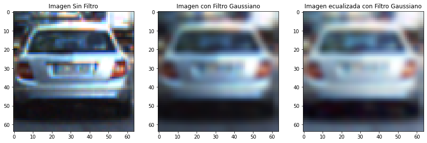

```python
res_gauss = cv2.GaussianBlur(img_G2,(5, 5),2)
res_gauss_ecua= cv2.GaussianBlur(res_ecua2,(5, 5),2)

fig, (ax1, ax2, ax3) = plt.subplots(1,3, figsize=(15, 6))
ax1.set_title("Imagen Sin Filtro")
ax1.imshow(img_G2)
ax2.set_title("Imagen con Filtro Gaussiano")
ax2.imshow(res_gauss)
ax3.set_title("Imagen ecualizada con Filtro Gaussiano")
ax3.imshow(res_gauss_ecua)
```

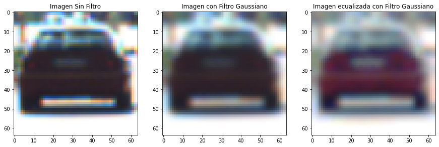

```python
img_rgb1 = img_read('/content/drive/MyDrive/GitHub/data/vehicles/'+image_path_one)
#Modelo RGB
img_G2 = img_rgb1

res_gauss = cv2.GaussianBlur(img_G2,(5, 5),2)
res_gauss_ecua= cv2.GaussianBlur(res_ecua,(5, 5),2)

fig, (ax1, ax2, ax3) = plt.subplots(1,3, figsize=(15, 6))
ax1.set_title("Imagen Sin Filtro")
ax1.imshow(img_G2)
ax2.set_title("Imagen con Filtro Gaussiano")
ax2.imshow(res_gauss)
ax3.set_title("Imagen ecualizada con Filtro Gaussiano")
ax3.imshow(res_gauss_ecua)
```

## Filtro de Media

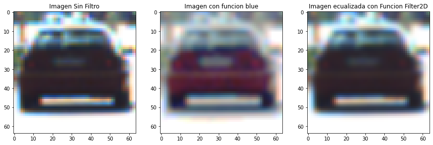

```python
k_size=3 #valor tamaño del kernel
#CANAL G - RGB
fmb_imagen5,fmd_imagen5 = filtro_mediab(res_ecua,k_size),filtro_media2d(img_G2,k_size)
#solo se mostro el filtro en la imagen 5

fig, (ax1, ax2, ax3) = plt.subplots(1,3, figsize=(15, 6))
ax1.set_title("Imagen Sin Filtro")
ax1.imshow(img_G2)
ax2.set_title("Imagen con funcion blue")
ax2.imshow(fmb_imagen5)
ax3.set_title("Imagen ecualizada con Funcion Filter2D")
ax3.imshow(fmd_imagen5)
```

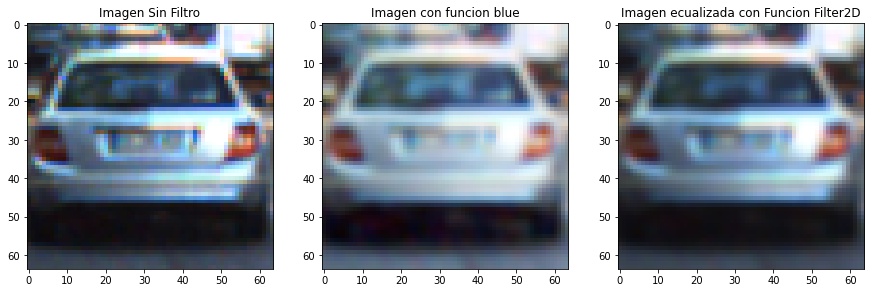

```python
k_size=3#valor tamaño del kernel

img_rgb1 = img_read('/content/drive/MyDrive/GitHub/data/vehicles/'+image_path)
#Modelo RGB
img_G2 = img_rgb1

#CANAL G - RGB
fmb_imagen5,fmd_imagen5 = filtro_mediab(res_ecua2,k_size),filtro_media2d(img_G2,k_size)
#solo se mostro el filtro en la imagen 5

fig, (ax1, ax2, ax3) = plt.subplots(1,3, figsize=(15, 6))
ax1.set_title("Imagen Sin Filtro")
ax1.imshow(img_G2)
ax2.set_title("Imagen con funcion blue")
ax2.imshow(fmb_imagen5)
ax3.set_title("Imagen ecualizada con Funcion Filter2D")
ax3.imshow(fmd_imagen5)
```

## Filtro mediana

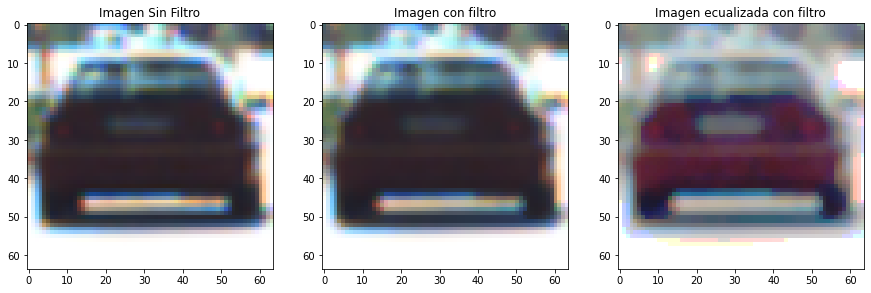

```python
#Definir tamaño del kernel
k_size = 3

img_rgb1 = img_read('/content/drive/MyDrive/GitHub/data/vehicles/'+image_path_one)
#Modelo RGB
img_G2 = img_rgb1

res1 = cv2.medianBlur(img_G2, k_size)
res2 = cv2.medianBlur(res_ecua, k_size)

fig, (ax1, ax2, ax3) = plt.subplots(1,3, figsize=(15, 6))
ax1.set_title("Imagen Sin Filtro")
ax1.imshow(img_G2)
ax2.set_title("Imagen con filtro")
ax2.imshow(res1)
ax3.set_title("Imagen ecualizada con filtro")
ax3.imshow(res2)
```

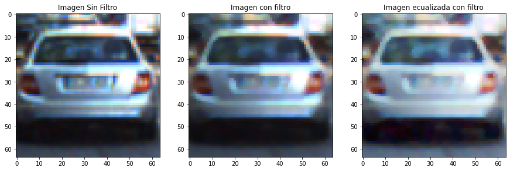

```python
#Definir tamaño del kernel
k_size = 3

img_rgb1 = img_read('/content/drive/MyDrive/GitHub/data/vehicles/'+image_path)
#Modelo RGB
img_G2 = img_rgb1

res1 = cv2.medianBlur(img_G2, k_size)
res2 = cv2.medianBlur(res_ecua2, k_size)

fig, (ax1, ax2, ax3) = plt.subplots(1,3, figsize=(15, 6))
ax1.set_title("Imagen Sin Filtro")
ax1.imshow(img_G2)
ax2.set_title("Imagen con filtro")
ax2.imshow(res1)
ax3.set_title("Imagen ecualizada con filtro")
ax3.imshow(res2)
```

## Filtro Minimo

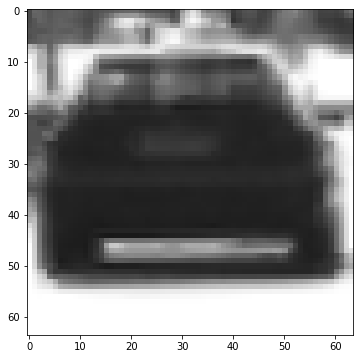

```python
k_size = 1

img_rgb1 = img_read('/content/drive/MyDrive/GitHub/data/vehicles/'+image_path_one)
#Modelo RGB
img_G2 = img_rgb1

fig, (ax1) = plt.subplots(1, figsize=(15, 6))
ax1.imshow(minimum_filter(img_rgb1, k_size))
```

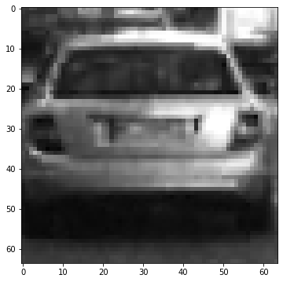

```python
k_size = 1

img_rgb1 = img_read('/content/drive/MyDrive/GitHub/data/vehicles/'+image_path)
#Modelo RGB
img_G2 = img_rgb1

fig, (ax1) = plt.subplots(1, figsize=(15, 6))
ax1.imshow(minimum_filter(img_rgb1, k_size))
```

## Filtro Maximo

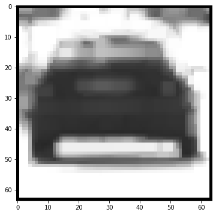

```python
k_size = 2

img_rgb1 = img_read('/content/drive/MyDrive/GitHub/data/vehicles/'+image_path_one)
#Modelo RGB
img_G2 = img_rgb1

fig, (ax1) = plt.subplots(1, figsize=(15, 6))
ax1.imshow(maximum_filter(img_rgb1, k_size))
```

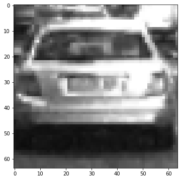

```python
k_size = 1

img_rgb1 = img_read('/content/drive/MyDrive/GitHub/data/vehicles/'+image_path)
#Modelo RGB
img_G2 = img_rgb1

fig, (ax1) = plt.subplots(1, figsize=(15, 6))
ax1.imshow(maximum_filter(img_rgb1, k_size))
```

## Preprocesamiento Seeleccionado

El comportamiento observado a lo largo de la implementacion de los filtros muestra que en la mayoria de los filtros en lugar de mejorar la imagen lo que hace es ponerla o borrosa o no resaltar las caracteristicas por lo cual el unico metodo que resalta las caracteristicas es la ecualizacion de la imagen y que en este caso es la escogida para formar parte del preprocesamiento

```python
def preprocessing(path):
    image = img_read('/content/drive/MyDrive/GitHub/data/vehicles/'+path)
    normalized = norm_image(image)
    res = histogram_equalization(image)
    filename = '/content/drive/MyDrive/GitHub/preprocesed/vehicles/'+path
    result = cv2.imwrite(filename, res)
    if result==True:
        pass
    else:
        print("Error in saving file")
```

```python
contenido = os.listdir('/content/drive/MyDrive/GitHub/data/vehicles/')
for i in contenido:
     preprocessing(i)
```

# Model processing - Car images

```python
pip install bayesian-optimization
```

```python
pip install split-folders
```

```python
# General Libraries

# Tensorflow
from tensorflow import keras
from tensorflow.keras.preprocessing.image import ImageDataGenerator
from tensorflow.keras.preprocessing import image
from tensorflow.keras.models import Sequential, Model, load_model
from tensorflow.keras.layers import GlobalAveragePooling2D, Dense, BatchNormalization, Dropout, Flatten, Conv2D, MaxPool2D
from tensorflow.keras.optimizers import Adam
from bayes_opt import BayesianOptimization
from keras.regularizers import L1L2

# Sklearn
from sklearn.model_selection import train_test_split
from sklearn.neighbors import KNeighborsClassifier
from sklearn.ensemble import RandomForestClassifier
from sklearn.metrics import confusion_matrix, accuracy_score, recall_score, precision_score, f1_score
from sklearn.metrics import precision_recall_fscore_support as score_f
from imutils import paths

import pandas as pd
import numpy as np
import seaborn as sns
import matplotlib.image as mpimg
import tensorflow as tf
import imutils
import shutil
import splitfolders
import cv2
import os
import glob
import random
import matplotlib.pyplot as plt
import os
import zipfile
import math
import pathlib

%matplotlib inline
```

```python
# General functions

def image_to_feature_vector(image, size=(32, 32)):
    # Convirtiendo imagen a un tamaño fijo y luego la aplanamos
    return cv2.resize(image, size).flatten()


def extract_color_histogram(image, bins=(8, 8, 8)):
    """This function allows us extract the histogram
    color for the images"""
  # Convertimos a HSV y obtenemos un histograma
    hsv = cv2.cvtColor(image, cv2.COLOR_BGR2HSV)
    hist = cv2.calcHist([hsv], [0, 1, 2], None, bins,
        [0, 180, 0, 256, 0, 256])
    # Normalizamos hist
    if imutils.is_cv2():
        hist = cv2.normalize(hist)
    else:
        cv2.normalize(hist, hist)
    return hist.flatten()


def show_pred(img_paths, preds, idxs):
    """This function allows us plot the
    images with their predictions"""
    plt.figure(figsize=(30, 20))
    plt.suptitle("Predictions", fontsize=40)
    diff_s = math.sqrt(idxs[1] - idxs[0])
    for img_idx in range(idxs[0], idxs[1]):
        filename = img_paths[img_idx]
        img = cv2.cvtColor(cv2.imread(filename),cv2.COLOR_BGR2RGB)
        plt.subplot(diff_s, diff_s, img_idx + 1)
        plt.title(f"Pred: {preds[img_idx]}")
        plt.imshow(img)
    plt.show()


def generate_training_img_set(path_train):
    """With this function we are going to genarate
    three vectors (images, features and labels) for
    the training set"""
    # Training set
    trainImages = []
    trainFeatures = []
    trainLabel = []

    for (i, imagePath) in enumerate(path_train):
        # read image & label
        image = cv2.imread(imagePath)
        if image is None:
            print("Wrong path: ", imagePath)
        else:
            label = imagePath.split(os.path.sep)[3]

            # Image characteristics and histogram
            pixels = image_to_feature_vector(image)
            hist = extract_color_histogram(image)

            # Saving in vectors
            trainImages.append(pixels)
            trainFeatures.append(hist)
            trainLabel.append(label)


    # We need to have only two classes
    trainLabel = ["non-vehicles" if "non-vehicles" in i else "vehicles" for i in trainLabel]

    # Convert into array
    trainImages = np.array(trainImages)
    trainFeatures = np.array(trainFeatures)
    trainLabel = np.array(trainLabel)

    return (trainImages, trainFeatures, trainLabel)


def generate_testing_img_set(path_test):
    """With this function we are going to genarate
    three vectors (images, features and labels) for
    the testing set"""
    # Testing set
    testImages = []
    testFeatures = []
    testLabel = []

    for (i, imagePath) in enumerate(path_test):
        # read image & label
        image = cv2.imread(imagePath)

        if image is None:
            print("Wrong path: ", imagePath)
        else:
            label = imagePath.split(os.path.sep)[3]

            # Image characteristics and histogram
            pixels = image_to_feature_vector(image)
            hist = extract_color_histogram(image)

            # Saving in vectors
            testImages.append(pixels)
            testFeatures.append(hist)
            testLabel.append(label)

    # We need to have only two classes
    testLabel = ["non-vehicles" if "non-vehicles" in i else "vehicles" for i in testLabel]

    # Convert into array
    testImages = np.array(testImages)
    testFeatures = np.array(testFeatures)
    testLabel = np.array(testLabel)

    return(testImages, testFeatures, testLabel)


def plot_confusion_matrix(df_confusion, title='Confusion matrix', cmap="viridis"):
    """Confusion Matrix plotting"""

    plt.figure(figsize = (10, 10))
    sns.heatmap(df_confusion, cmap=cmap, fmt='.0f', annot=True,
               linewidths=.5) # imshow

    tick_marks = np.arange(len(df_confusion.columns))
    plt.xticks(tick_marks, df_confusion.columns, rotation=45)
    plt.yticks(tick_marks, df_confusion.index)
    plt.ylabel(df_confusion.index.name)
    plt.xlabel(df_confusion.columns.name)
    plt.title(title)


def clear_all():
    tf.keras.backend.clear_session()
    os.environ['TF_CUDNN_DETERMINISTIC'] = '1'
    os.environ['TF_DETERMINISTIC_OPS'] = '1'
    random.seed(42)
    np.random.seed(42)
    tf.random.set_seed(42)


def view_random_image(target_dir, target_class):

    # Setup the target directory (we'll view images from here)
    target_folder = target_dir+target_class

    # Get a random image path
    random_image = random.sample(os.listdir(target_folder), 1)
    print(random_image)

    # Read in the image and plot it using matplotlib
    img = mpimg.imread(target_folder + "/" + random_image[0])
    plt.imshow(img)
    plt.title(target_class)
    plt.axis("off");

    print(f"Image shape: {img.shape}") # show the shape of the image

    return img


class myCallback(tf.keras.callbacks.Callback):
    def on_epoch_end(self, epoch, logs={}):
        if(logs.get('accuracy') > .95):
            print("Reached 80% accuracy so cancelling training!")
            self.model.stop_training = True
```

```python
# We need to generate our train|val|test set for data with preprocessing
input_file = "/content/drive/MyDrive/GitHub/preprocesed"

splitfolders.ratio(input_file, output="/output_data_preprocessed", seed=1337, ratio=(.8, .1, .1))
```

```
Copying files: 17760 files [07:23, 40.00 files/s]
```

```python
# We need to generate our train|val|test set for data without preprocessing
input_file = "/content/drive/MyDrive/GitHub/data"

splitfolders.ratio(input_file, output="/output_data", seed=1337, ratio=(.8, .1, .1))
```

```
Copying files: 17760 files [05:46, 51.20 files/s]
```

## Process with preprocessed data

```python
# General route
train_dir = "/output_data_preprocessed/train"
validation_dir = "/output_data_preprocessed/val"
testing_dir = "/output_data_preprocessed/test"

# Training route vehicles & non vehicles
train_vehicles_dir = os.path.join(train_dir, "vehicles")
train_no_vehicles_dir = os.path.join(train_dir, "non-vehicles")

# Validation roude vehicles & non vehicles
validation_vehicles_dir = os.path.join(validation_dir, "vehicles")
validation_no_vehicles_dir = os.path.join(validation_dir, "non-vehicles")

# Test roude vehicles & non vehicles
test_vehicles_dir = os.path.join(testing_dir, "vehicles")
test_no_vehicles_dir = os.path.join(testing_dir, "non-vehicles")
```

```python
# Creating training set
vehicle_train = glob.glob(train_vehicles_dir + "/*")
no_vehicle_train = glob.glob(train_no_vehicles_dir + "/*")
path_train = vehicle_train + no_vehicle_train
random.shuffle(path_train)

# Creating testing set
vehicle_test = glob.glob(test_vehicles_dir + "/*")
no_vehicle_test = glob.glob(test_no_vehicles_dir + "/*")
path_test = vehicle_test + no_vehicle_test
random.shuffle(path_test)

# Creating validation set
vehicle_val = glob.glob(validation_vehicles_dir + "/*")
no_vehicle_val = glob.glob(validation_no_vehicles_dir + "/*")
path_val = vehicle_val + no_vehicle_val
random.shuffle(path_val)
```

```python
# Obtaining images, features and labels for the training set
trainImages, features_train, trainImagesLabels = generate_training_img_set(path_train)

# Obtaining images, features and labels for the training set
testImages, features_test, testImagesLabels = generate_testing_img_set(path_test)

print("Len trainImages: ", len(trainImages))
print("Len trainImagesLabels: ", len(trainImagesLabels))
print("Len testImages: ", len(testImages))
print("Len testImagesLabels: ", len(testImagesLabels))
```

```
Len trainImages:  14207
Len trainImagesLabels:  14207
Len testImages:  1778
Len testImagesLabels:  1778
```

### First model | KNN

```python
# We need to define the number of neighbors to divide our two classes, in that case it will be 2
NEIGHBORS = 2
SEED = 10

# Training KNN using flatten images
knn_model_imgs = KNeighborsClassifier(n_neighbors=NEIGHBORS, n_jobs=-1)
knn_model_imgs.fit(trainImages, trainImagesLabels)
acc = knn_model_imgs.score(testImages, testImagesLabels)
print("Precisión por píxel: {:.2f}%".format(acc * 100))
```

```
Precisión por píxel: 92.07%
```

```python
# Predictions over test set
pred_knn_imgs = knn_model_imgs.predict(testImages)

# Confusion Matrix
y_actu = pd.Series(testImagesLabels)
y_pred = pd.Series(pred_knn_imgs)
df_confusion = pd.crosstab(y_actu, y_pred, rownames=['Actual'], colnames=['Predicted'], margins=True)
```

```python
df_confusion
```

| Predicted Actual | non-vehicles | vehicles | All |
| --- | --- | --- | --- |
| non-vehicles | 898 | 0 | 898 |
| vehicles | 141 | 739 | 880 |
| All | 1039 | 739 | 1778 |

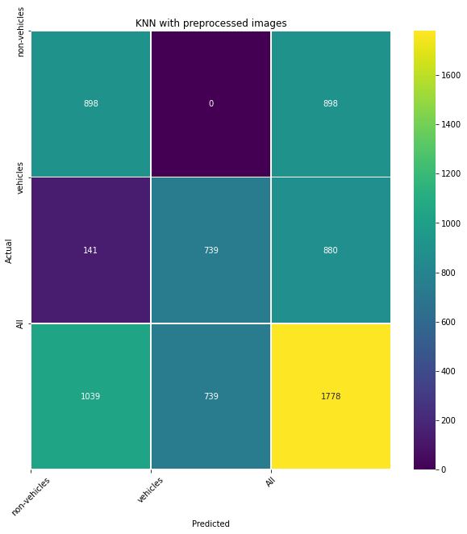

```python
plot_confusion_matrix(df_confusion,  title='KNN with preprocessed images')
```

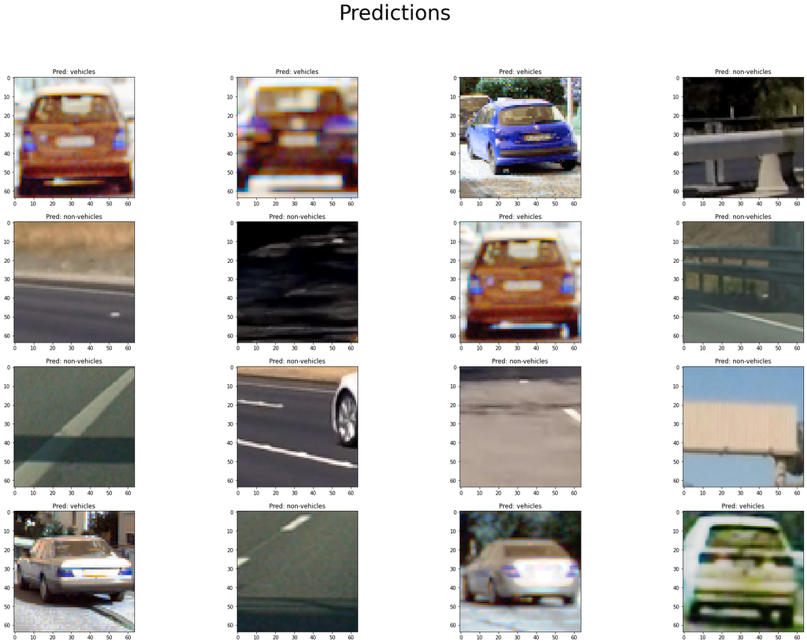

```python
# Visualize the predictions per image
show_pred(path_test, pred_knn_imgs, (0, 16))
```

```python
# Computing metrics from confusion matrix to evaluate the model's performance
precision, recall, fscore, support = score_f(y_actu, y_pred)

print('precision: {}'.format(precision))
print('recall: {}'.format(recall))
print('fscore: {}'.format(fscore))
print('support: {}'.format(support))

metrics_result_knn_p = {"model": "KNN_p","accuracy": acc, "recall": recall,
                 "precision_score": precision, "f1_score": fscore, "support": support}
```

```
precision: [0.86429259 1.        ]
recall: [1.         0.83977273]
fscore: [0.92720702 0.9129092 ]
support: [898 880]
```

### Second model | CNN

```python
# Seeing directories
!ls -la /output_data_preprocessed/
```

```
total 20
drwxr-xr-x 5 root root 4096 Dec 29 16:25 .
drwxr-xr-x 1 root root 4096 Dec 29 16:28 ..
drwxr-xr-x 4 root root 4096 Dec 29 16:28 test
drwxr-xr-x 4 root root 4096 Dec 29 16:26 train
drwxr-xr-x 4 root root 4096 Dec 29 16:28 val
```

```python
# Walk through Car directory and list number of files
for dirpath, dirnames, filenames in os.walk("/output_data_preprocessed"):
      print(f"There are {len(dirnames)} directories and {len(filenames)} images in '{dirpath}'.")
```

```
There are 3 directories and 0 images in '/output_data_preprocessed'.
There are 2 directories and 0 images in '/output_data_preprocessed/train'.
There are 0 directories and 7174 images in '/output_data_preprocessed/train/non-vehicles'.
There are 0 directories and 7033 images in '/output_data_preprocessed/train/vehicles'.
There are 2 directories and 0 images in '/output_data_preprocessed/test'.
There are 0 directories and 898 images in '/output_data_preprocessed/test/non-vehicles'.
There are 0 directories and 880 images in '/output_data_preprocessed/test/vehicles'.
There are 2 directories and 0 images in '/output_data_preprocessed/val'.
There are 0 directories and 896 images in '/output_data_preprocessed/val/non-vehicles'.
There are 0 directories and 879 images in '/output_data_preprocessed/val/vehicles'.
```

```python
# Get the classnames programmatically
data_dir = pathlib.Path("/output_data_preprocessed/train")
class_names = np.array(sorted([item.name for item in data_dir.glob("*")])) # Created a list of class_names from the subdirectories
print(class_names)
```

```
['non-vehicles' 'vehicles']
```

```python
# We need to define the image shape
img_shape = (64, 64)

# General route
train_dir = "/output_data_preprocessed/train"
validation_dir = "/output_data_preprocessed/val"
testing_dir = "/output_data_preprocessed/test"

# seed defined and batch size
SEED = 10
BATCH_SIZE = 32 #Number of images per mini-batch
```

```python
# We convert the images to floating point, and rescale them to values between 0 and 1.
# These imagers will allow to convert data from image files to tensors

# Data partition test/validation/train
# Normalizing process
train_data_generator = ImageDataGenerator()
val_data_generator = ImageDataGenerator()
test_data_generator = ImageDataGenerator()

# Sampling generation
training_generator = train_data_generator.flow_from_directory(train_dir,
                                                          target_size = img_shape,
                                                          shuffle = True, # Randomly selection
                                                          seed = SEED,
                                                          class_mode = 'binary',# we use a binary loss function, the class must be binary
                                                          batch_size = BATCH_SIZE,# Number of images per mini-batch, our model will process simultaneously 32 images instead the whole dataset
                                                          subset = 'training')
training_sample = training_generator.samples
validation_generator = val_data_generator.flow_from_directory(validation_dir,
                                                          target_size = img_shape,
                                                          shuffle = False,
                                                          seed = SEED,
                                                          class_mode = 'binary',
                                                          batch_size = BATCH_SIZE,
                                                          #subset = 'training'
                                                          )
validation_sample = validation_generator.samples
testing_generator = test_data_generator.flow_from_directory(testing_dir,
                                                          target_size = img_shape,
                                                          shuffle = False,
                                                          seed = SEED,
                                                          class_mode = 'binary',
                                                          batch_size = BATCH_SIZE)
testing_sample = testing_generator.samples

# Number of classes
classes = list(training_generator.class_indices.keys())
print("Number of classes: " + str(len(classes)))
```

```
Found 14207 images belonging to 2 classes.
Found 1775 images belonging to 2 classes.
Found 1778 images belonging to 2 classes.
Number of classes: 2
```

```python
# Defining callback
callback = myCallback()

def model_cnn_p(regularizer, dropout, learnrate):
    model_cnn_p = Sequential([
        Conv2D(32, (3,3), activation='relu', input_shape=(img_shape[0],
                                                          img_shape[1], 3),
              kernel_regularizer = L1L2(l1 = 0, l2 = regularizer)),
        MaxPool2D(2, 2),
        Conv2D(64, (3,3), activation='relu'),
        MaxPool2D(2,2),
        Flatten(),
        Dense(128, activation='relu'),
        Dropout(dropout),
        Dense(1, activation='sigmoid')
    ])

    # Adam optimizer
    opt = tf.keras.optimizers.Adam(learning_rate=learnrate)

    # Define the model optimizer, loss function and metrics
    model_cnn_p.compile(optimizer=opt, loss='binary_crossentropy',
                        metrics=['accuracy'])

    # Training
    history = model_cnn_p.fit(
            training_generator,
            steps_per_epoch=len(training_generator),
            epochs=5,
            callbacks = callback,
            validation_data=validation_generator,
            verbose = 1,
            validation_steps=len(validation_generator))

    score = history.model.evaluate_generator(validation_generator)[1]

    return score
```

```python
# Bayesian optimization
pbounds = {'regularizer': (0.001,6),
       "dropout": (0.01,0.95),
       'learnrate': (0.000001, 0.01)
      }


optimizer = BayesianOptimization(
f=model_cnn_p,
pbounds=pbounds,
random_state=1,
verbose=2)


optimizer.maximize(init_points=5, n_iter=10)
```

```
|   iter    |  target   |  dropout  | learnrate | regula... |
-------------------------------------------------------------
```

```
|  1        |  0.4952   |  0.402    |  0.007204 |  0.001686 |
|  2        |  0.9786   |  0.2942   |  0.001468 |  0.5549   |
|  3        |  0.5042   |  0.1851   |  0.003456 |  2.381    |
|  4        |  0.4952   |  0.5165   |  0.004193 |  4.112    |
|  5        |  0.5651   |  0.2022   |  0.008781 |  0.1653   |
```

```
|  6        |  0.893    |  0.2962   |  1e-06    |  0.7124   |
```

```
|  7        |  0.8845   |  0.5629   |  1e-06    |  0.5678   |
```

```
|  8        |  0.9454   |  0.01323  |  0.008127 |  0.6097   |
```

```
|  9        |  0.9831   |  0.2239   |  0.001557 |  5.684    |
```

```
|  10       |  0.5718   |  0.6927   |  0.007286 |  1.169    |
```

```
|  11       |  0.5059   |  0.4949   |  0.005457 |  6.0      |
```

```
|  12       |  0.5341   |  0.9081   |  0.006641 |  2.825    |
```

```
|  13       |  0.9583   |  0.4694   |  0.008412 |  5.874    |
```

```
|  14       |  0.56     |  0.3131   |  0.007636 |  5.142    |
```

```
|  15       |  0.5735   |  0.8137   |  0.007194 |  5.472    |
=============================================================
```

```python
# Params obtained with B-P
params_weighted = optimizer.max["params"]
regularizer = params_weighted["regularizer"]
dropout = params_weighted["dropout"]
learnrate = params_weighted["learnrate"]
```

```python
model_cnn_p = Sequential([
        Conv2D(32, (3,3), activation='relu', input_shape=(img_shape[0],
                                                          img_shape[1], 3),
              kernel_regularizer = L1L2(l1 = 0, l2 = regularizer)),
        MaxPool2D(2, 2),
        Conv2D(64, (3,3), activation='relu'),
        MaxPool2D(2,2),
        Flatten(),
        Dense(128, activation='relu'),
        Dropout(dropout),
        Dense(1, activation='sigmoid')
    ])

# Adam optimizer
opt = tf.keras.optimizers.Adam(learning_rate=learnrate)

# Define the model optimizer, loss function and metrics
model_cnn_p.compile(optimizer=opt, loss='binary_crossentropy',
                    metrics=['accuracy'])

# Training
history = model_cnn_p.fit(
        training_generator,
        steps_per_epoch=len(training_generator),
        epochs=5,
        callbacks = callback,
        validation_data=validation_generator,
        verbose = 1,
        validation_steps=len(validation_generator))

score = history.model.evaluate_generator(validation_generator)[1]
```

##### Saving the model

```python
model_path = "./persisted_model"
print(model_path)
model_cnn_p.save(model_path, save_format="tf")
# Load model
model_cnn_p = load_model(model_path)
```

```
./persisted_model
INFO:tensorflow:Assets written to: ./persisted_model/assets
```

##### Evaluating model

```python
# Using the test dataset with the loaded model
score_test = model_cnn_p.evaluate(testing_generator)
print('Test loss:', score_test[0])
print('Test accuracy:', score_test[1])

# Using the validation dataset
score_val = model_cnn_p.evaluate(validation_generator)
print('Val loss:', score_val[0])
print('Val accuracy:', score_val[1])
```

```
Test loss: 1.0873887538909912
Test accuracy: 0.967379093170166
Val loss: 1.0879244804382324
Val accuracy: 0.9656338095664978
```

```python
# Predict with test set
pred_cnn = model_cnn_p.predict(testing_generator)

y_actu = pd.Series(testing_generator.classes)
y_pred = pd.Series(np.argmax(pred_cnn, axis=1))
df_confusion = pd.crosstab(y_actu, y_pred, rownames=['Actual'], colnames=['Predicted'], margins=True)
```

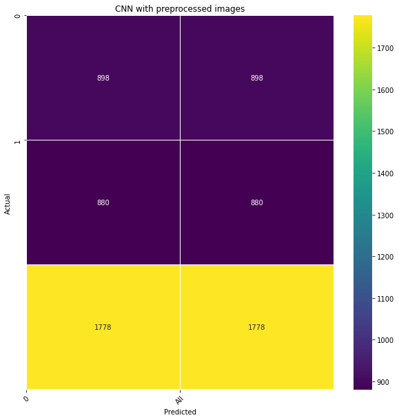

```python
plot_confusion_matrix(df_confusion,title='CNN with preprocessed images')
```

```python
# Computing metrics from confusion matrix to evaluate the model's performance
precision, recall, fscore, support = score_f(y_actu, y_pred)

print('precision: {}'.format(precision))
print('recall: {}'.format(recall))
print('fscore: {}'.format(fscore))
print('support: {}'.format(support))

metrics_result_cnn_p = {"model": "CNN_p","accuracy": score_test, "recall": recall,
                 "precision_score": precision, "f1_score": fscore, "support": support}
```

```
precision: [0.50506187 0.        ]
recall: [1. 0.]
fscore: [0.67115097 0.        ]
support: [898 880]
```

### Third model | Random Forest

**n_estimators**: This is the number of trees you want to build before taking the maximum voting or averages of predictions.

```python
# Creating RandomForest model
clf_p = RandomForestClassifier(n_estimators = 210, random_state = SEED)
# Training with flatten images
clf_p.fit(trainImages, trainImagesLabels)

# Score (Accuracy)
acc_p = clf_p.score(testImages, testImagesLabels)
print("Precisión por píxel: {:.2f}%".format(acc * 100))
```

[output not shown]

```python
# Predict with test set
pred_clf_p = clf_p.predict(testImages)

y_actu = pd.Series(testImagesLabels)
y_pred = pd.Series(pred_clf_p)
df_confusion = pd.crosstab(y_actu, y_pred, rownames=['Actual'], colnames=['Predicted'], margins=True)
```

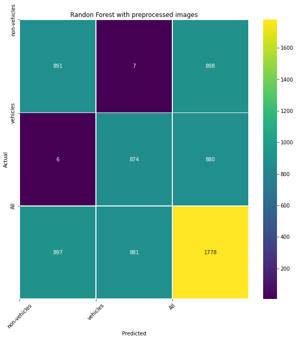

```python
plot_confusion_matrix(df_confusion, title='Randon Forest with preprocessed images')
```

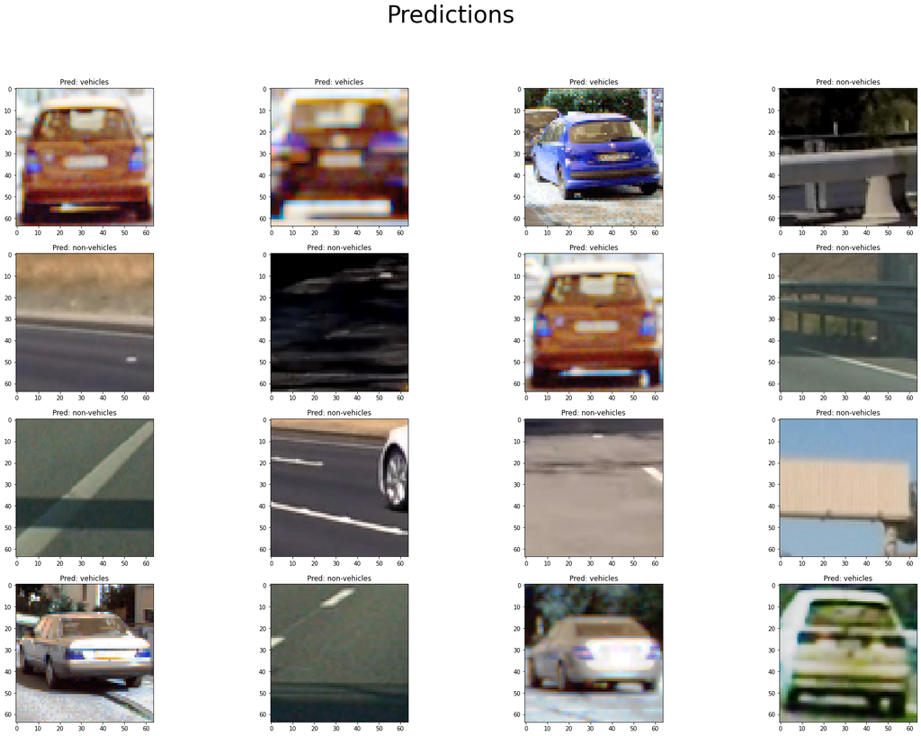

```python
# Visualize the predictions per image
show_pred(path_test, pred_clf_p, (0, 16))
```

```python
# Computing metrics from confusion matrix to evaluate the model's performance
precision, recall, fscore, support = score_f(y_actu, y_pred)

print('precision: {}'.format(precision))
print('recall: {}'.format(recall))
print('fscore: {}'.format(fscore))
print('support: {}'.format(support))

metrics_result_rf_p = {"model": "RF_p","accuracy": acc, "recall": recall,
                 "precision_score": precision, "f1_score": fscore, "support": support}
```

```
precision: [0.99331104 0.99205448]
recall: [0.9922049  0.99318182]
fscore: [0.99275766 0.99261783]
support: [898 880]
```